# database_structure – VegVault

### Gridpoints (`AbioticDataReference`)

Gridpoints are stored in artificially created `Datasets` and `Samples`, with one `Dataset` holding more `Samples` only if they differ in age. We have estimated the spatial and temporal distance between each `gridpoint` and other non-`gridpoint` `Samples` (`vegetation_plot`, `fossil_pollen_archive`, and `traits`). We store the link between `gridpoint` and non-`gridpoint` `Samples` as well as the spatial and temporal distance. As this results in very large amounts of data, we have discarded any `gridpoint` `Sample`, which is not close to 50 km and/or 5000 years to any other non-`gridpoint` `Samples` as not relevant for the vegetation dynamics.

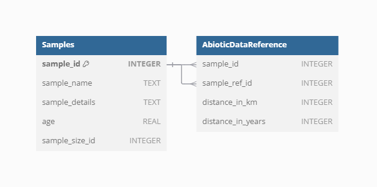

| column_name | data_type | description |
| --- | --- | --- |
| sample_id | INTEGER | ID of non-gridpoint Sample |
| sample_ref_id | INTEGER | ID of gridpoint Sample |
| distance_in_km | INTEGER | Distance among samples expressed in kilometres |
| distance_in_years | INTEGER | Distance among samples expressed in years |

Column names and types for table AbioticDataReference.

Such data structure allows that environmental context is readily available for each vegetation and trait `Sample`. For each non-`gridpoint` `Sample`, users can select the closest spatio-temporally abiotic data or get average from all surrounding `gridpoints`.

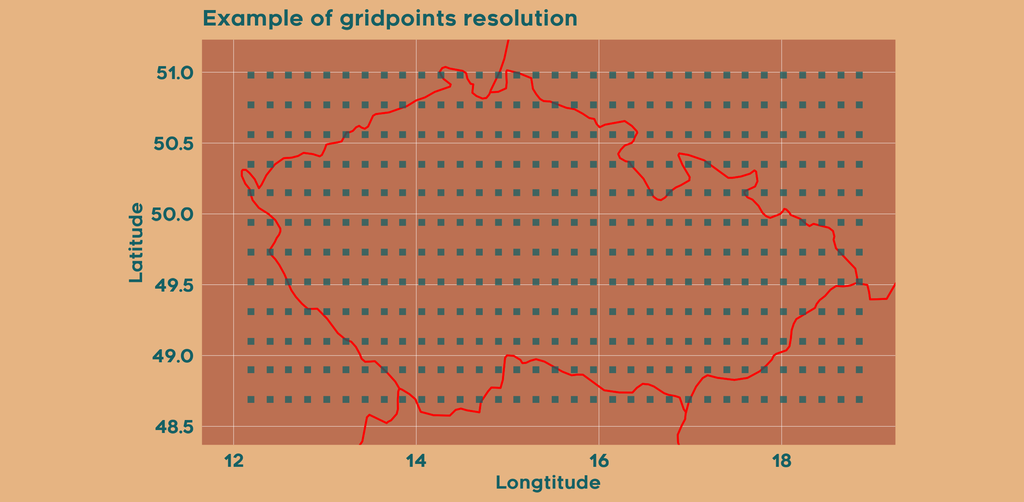

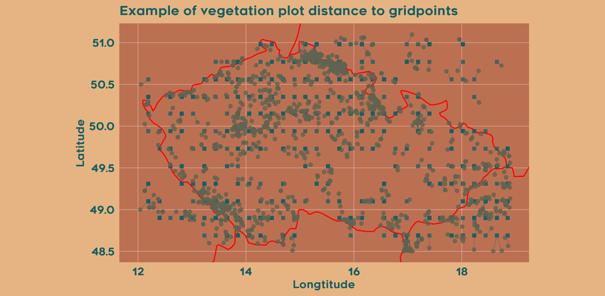

### Abiotic Variable Reference (`AbioticVariableReference`)

Each `Abiotic Variable` can have a separate `Reference`, in addition to a `Dataset` and `Sample`.

| column_name | data_type | description |
| --- | --- | --- |
| abiotic_variable_id | INTEGER | ID of an Abiotic Variable |
| reference_id | INTEGER | ID of a Reference |

Column names and types for table AbioticVariableReference.

The `References` table is a central component that serves all sections of the **VegVault** database. This table contains all `References`, independent of the source of the reference and the type of data. Each row contains a single `Reference`, which is then linked to the type of data which is being referenced. This allows a single `Reference` to be used across data types, but also one data point having many different references.

Moreover, most primary sources of the data have a license, which requires correct attribution. Therefore, each `Reference` has information if such a `Reference` needs to be cited while using the specific data.

Back to top